# Experiment 1

### Experiment summary

‘The aim was to demonstrate the validity of the response mapping function which was added to the 2HTM in order to make it appropriate for the analysis of confidence rating data.’ Data from 68 participants are included in the analysis. Participants were assigned randomly to two groups that differed on the wording of the response scales. The ‘strong wording’ condition where the end categories of the scale read ‘absolutely sure old/new’ and were further emphasized with red exclamation marks, and the ‘weak wording’ condition where the end labels read ‘pretty sure old/new’. During the learning phase of the experiment each participant saw 120 simple line drawings for 1.5 sec each, selected randomly from a set used previously in other studies. In the next phase, participants were presented with all (240) items of the set - hence half of the stimuli new and half of them old - and instructed to use extreme ratings only in the case of absolute certainty for ‘strong wording’ condition, or encouraged to use the complete scale for ‘weak wording’ condition. They received points for each correct answer and lost points for each wrong answer.

The manipulation accross conditions was effective: larger proportion of extreme ratings in the ‘weak wording’ condition than the ‘strong wording’. This manipulation was expected to not affect the core parameters, but to have a significant effect on the extreme rating parameters (r_1,r_8,q_1,q_8). Indeed, no core parameter was affected by the manipulation, while comparing across conditions, the probabailities of using extreme ratings were affected both in the detect and the uncertainty state. Also, the probabilities of extreme responses were higher in the detect state. The same pattern was observed both with aggregated and individual data analysis.

### Some information on the models

**Model Original:** q_2 = q_7, q_3 = q_6 & r_3 = r_6 (all but highest confidence response mapping of uncertainty states equated and lowest two confidence response mapping of detection states equated)  
**Q restricted:** q_2 = q_7, q_3 = q_6 (all but highest confidence response mapping of uncertainty states equated)  
**R restricted:** r_3 = r_6 (lowest two confidence response mapping of detection states equated)

### Some information on convergence

#### For Model Original

One approach failed:  
partial, TreeBUGS, beta

Frequentist approach with complete pooling had no convergence problems (asymptotic.complete.MPTinR).

Bayesian approach with no pooling (simple.no.TreeBUGS) had 2 parameters with Rhat > 1.05.  
Bayesian approach with complete pooling (simple.complete.TreeBUGS) converged well, all Rhat < 1.05.  
Bayesian approach with partial pooling (trait.partial.Treebugs) had 3 parameters with Rhat > 1.05 but (trait_uncorrelated.partial.TreeBUGS) converged well, all Rhat < 1.05.

#### For Q restricted

Two approaches failed: partial, TreeBUGS, beta  
partial, TreeBUGS, trait

Bayesian approach with no pooling (simple.no.TreeBUGS) had 2 parameters with Rhat > 1.05.  
Bayesian approach with complete pooling (simple.complete.TreeBUGS) had 14 parameters with Rhat > 1.05.  
Bayesian approach with partial pooling uncorrelated (trait_uncorrelated.partial.TreeBUGS) converged well, all Rhat < 1.05.

#### For R restricted

One approach failed: partial, TreeBUGS, beta

Frequentist approach with complete pooling had no convergence problems (asymptotic.complete.MPTinR).

Bayesian approach with no pooling (simple.no.TreeBUGS) had 44 parameters with Rhat > 1.05.  
Bayesian approach with complete pooling (simple.complete.TreeBUGS) converged well, all Rhat < 1.05.  
Bayesian approach with partial pooling (trait.partial.TreeBUGS) had 33 parameters with Rhat > 1.05 but uncorrelated (trait_uncorrelated.partial.TreeBUGS) had 1 parameter with Rhat > 1.05.

### Parameter estimation

**Model Original**

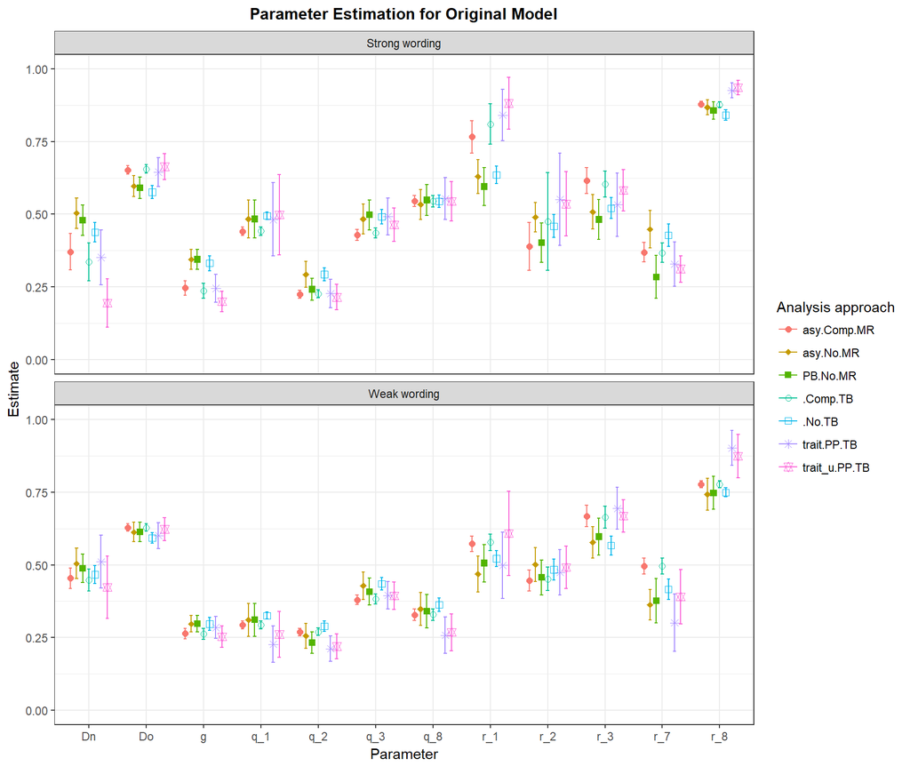

**Q restricted**

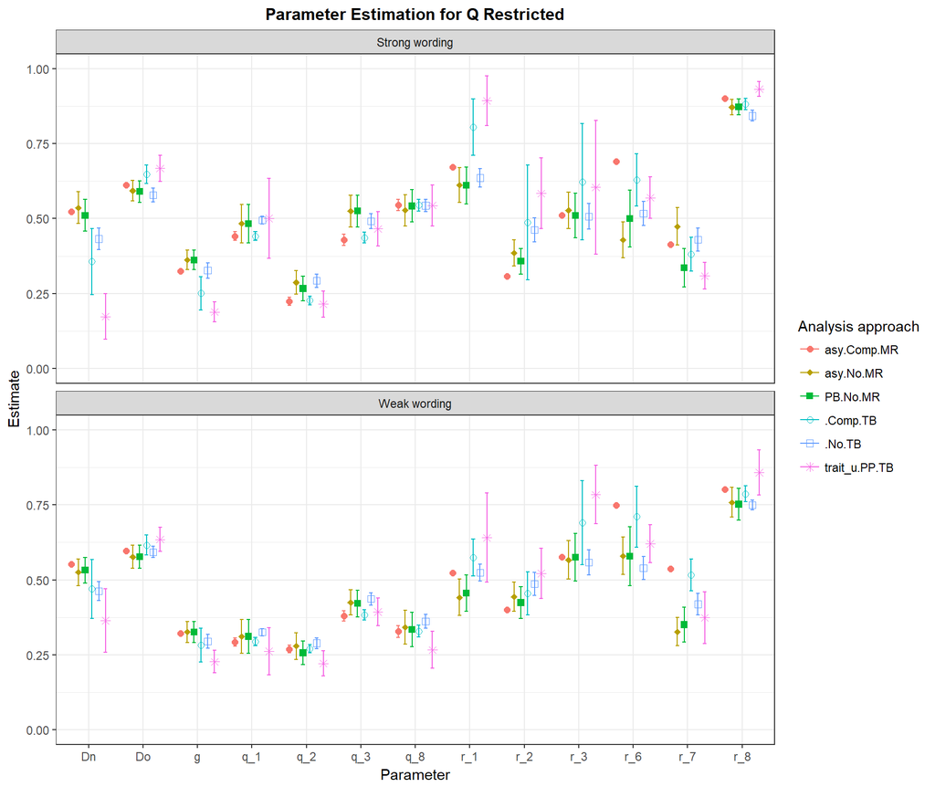

**R restricted**

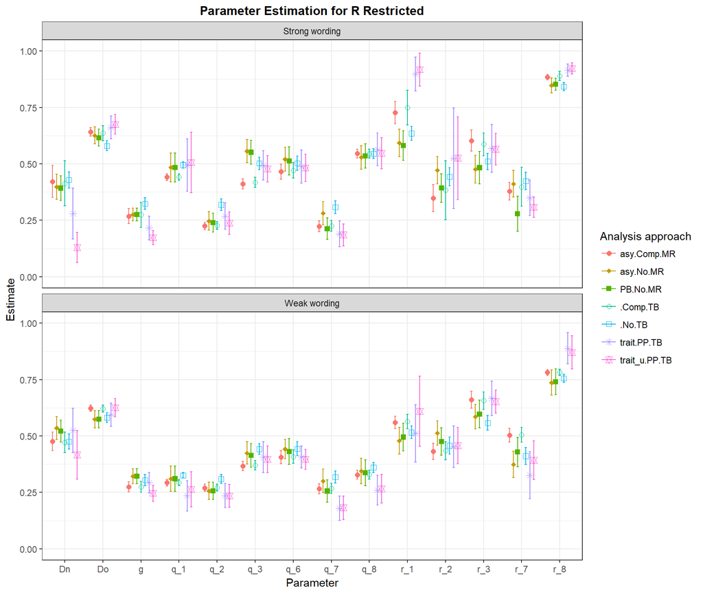

**Core parameters**

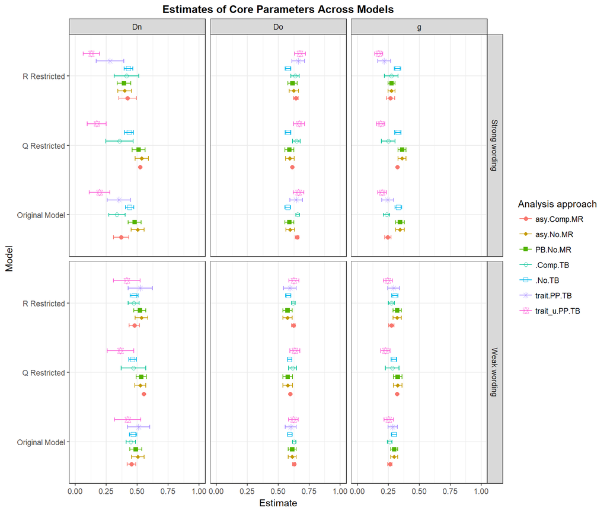

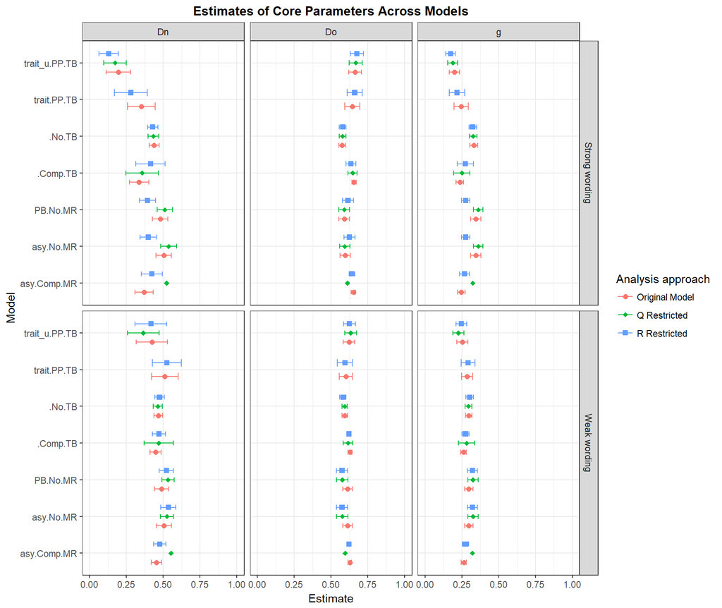

**Q parameters**

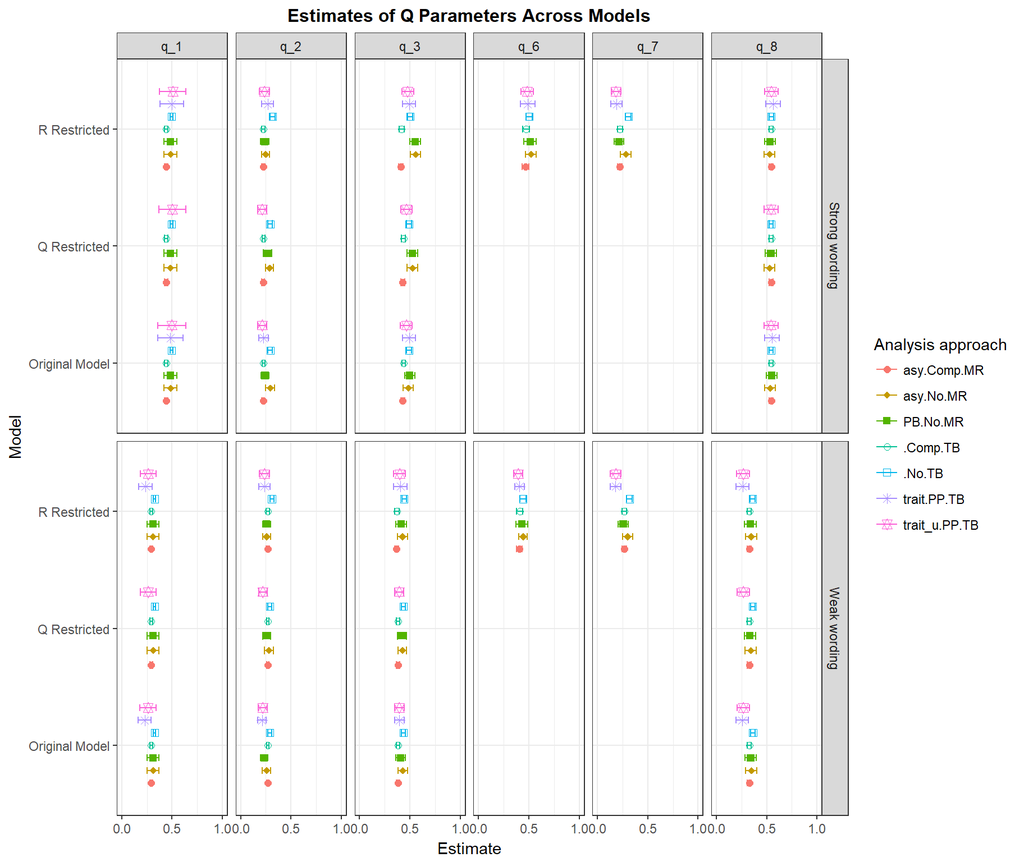

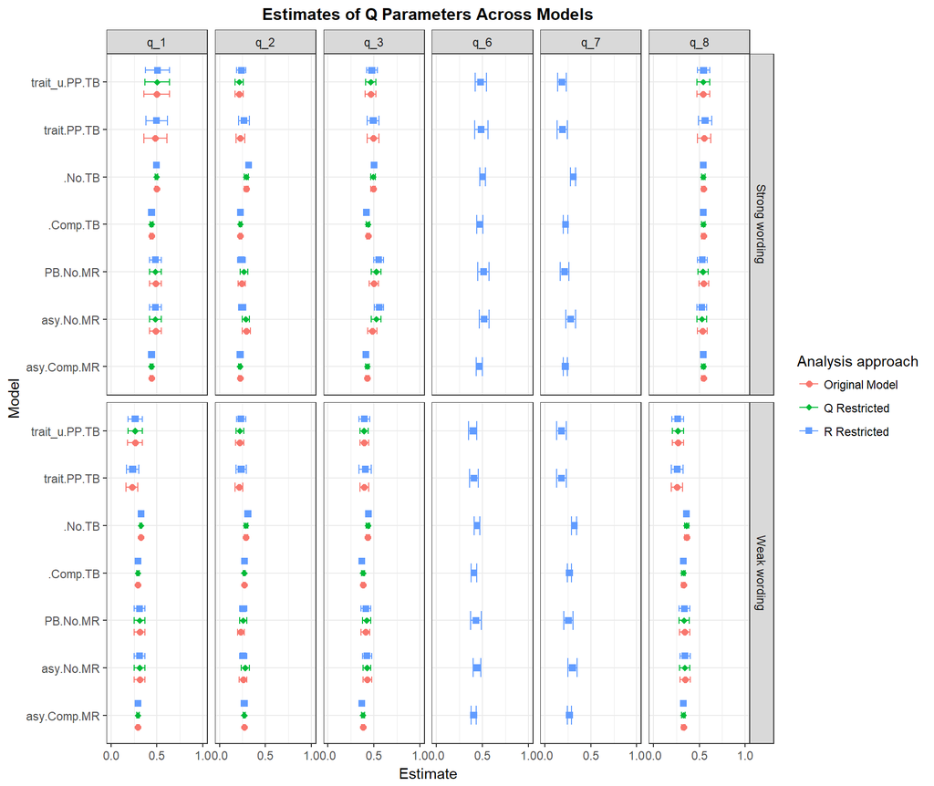

**R parameters**

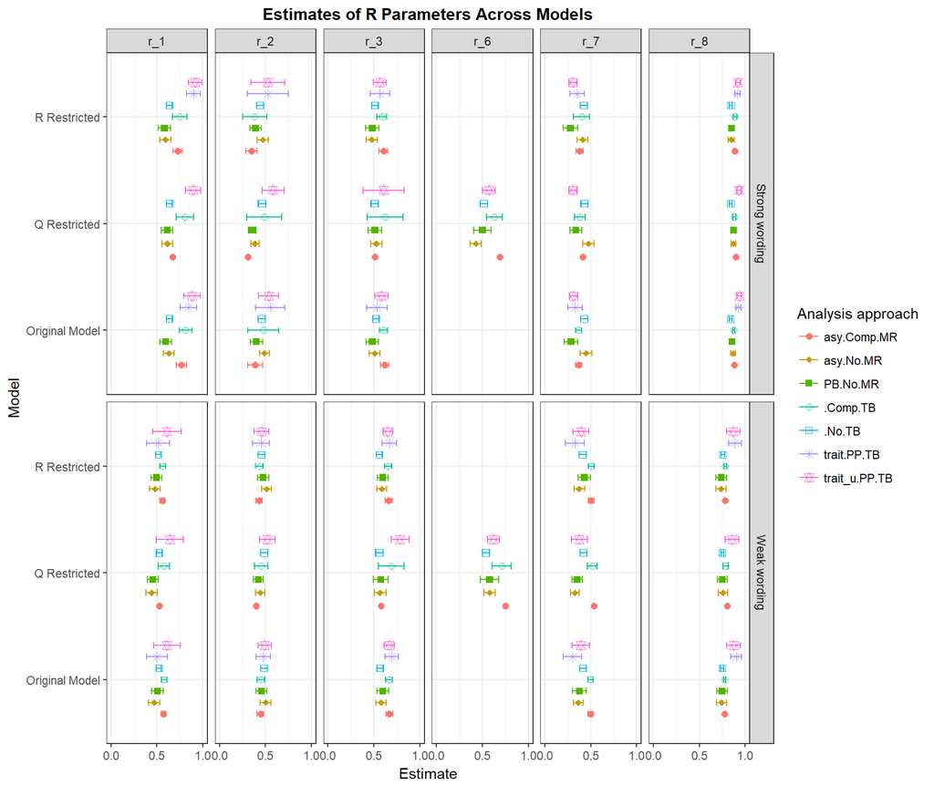

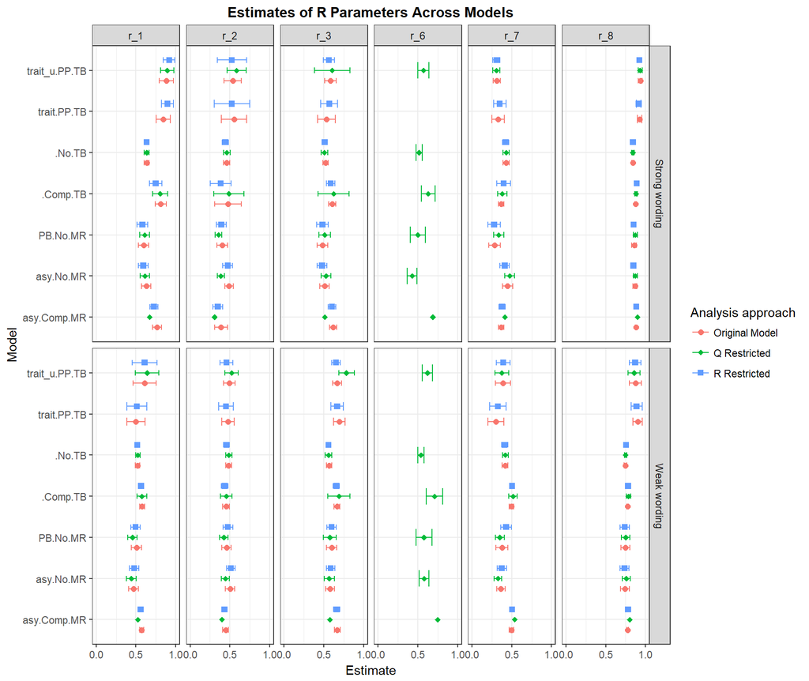

### Estimated differences

**Model Original**

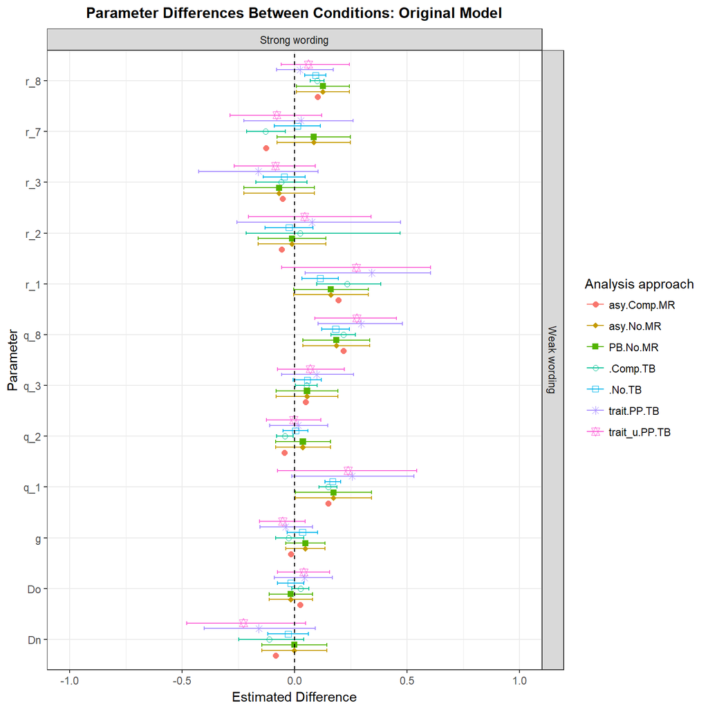

**Q restricted**

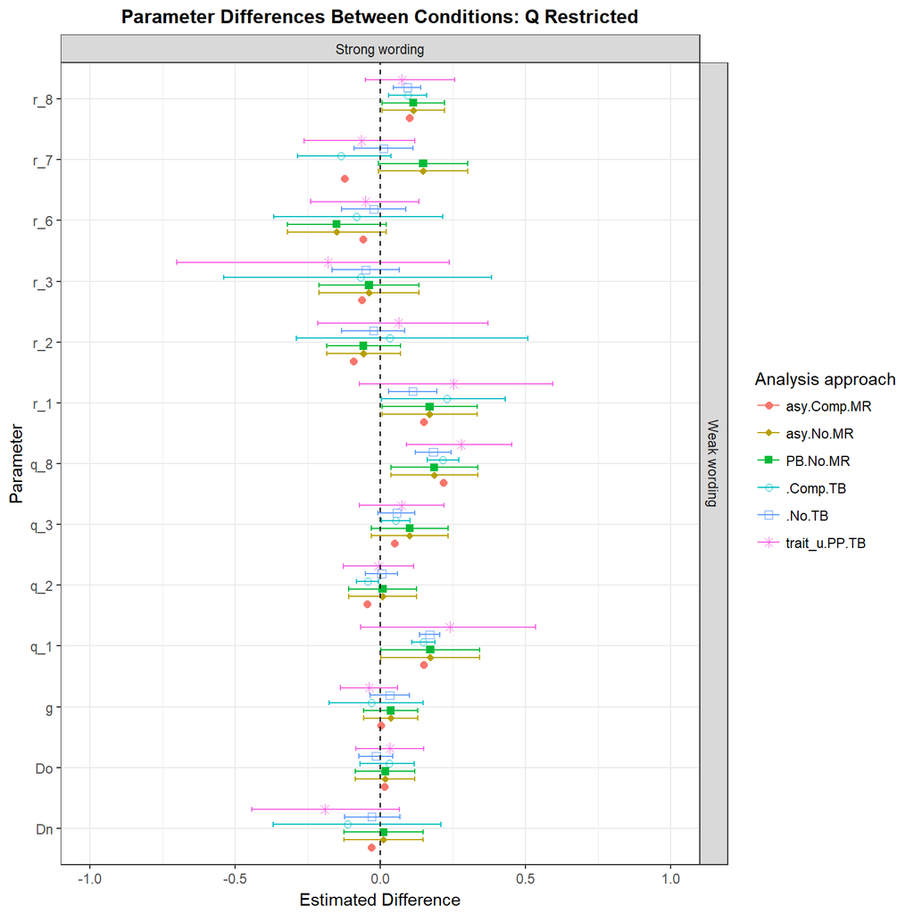

**R restricted**

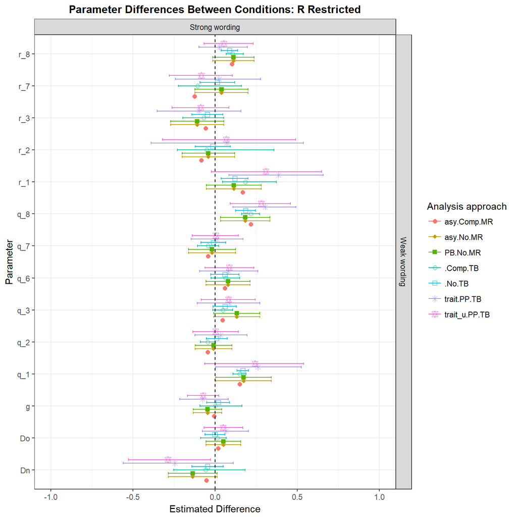

**Core parameters**

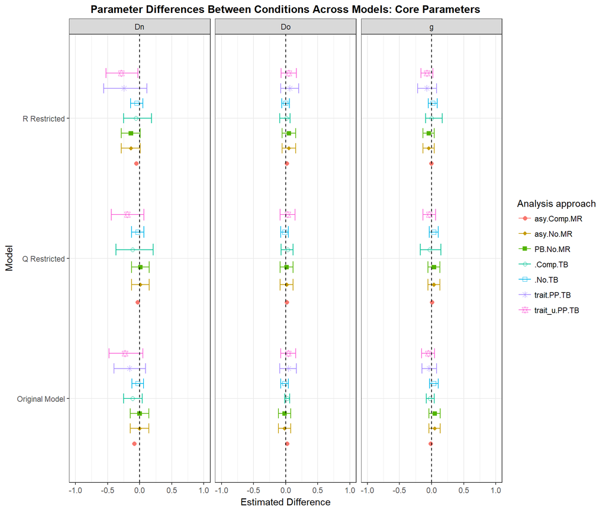

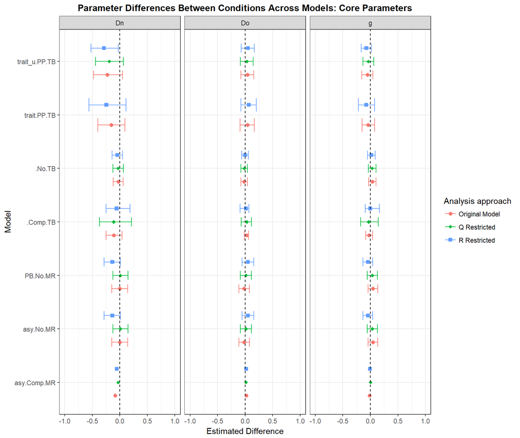

**Q Parameters**

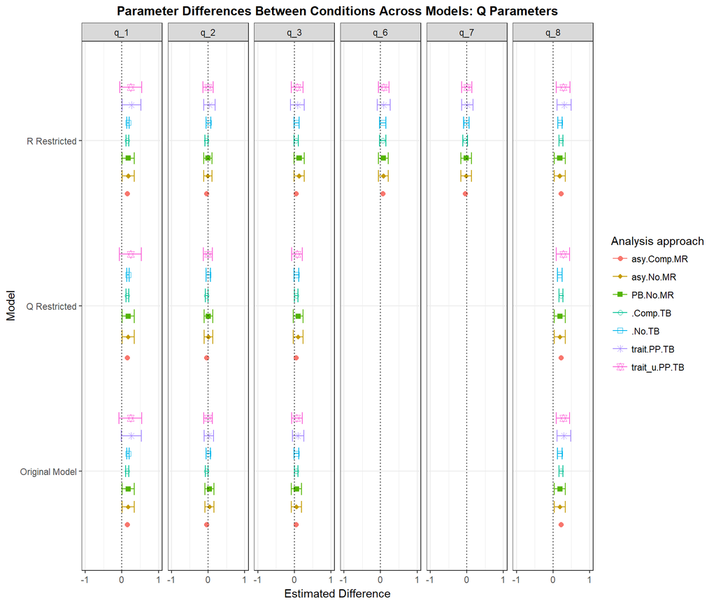

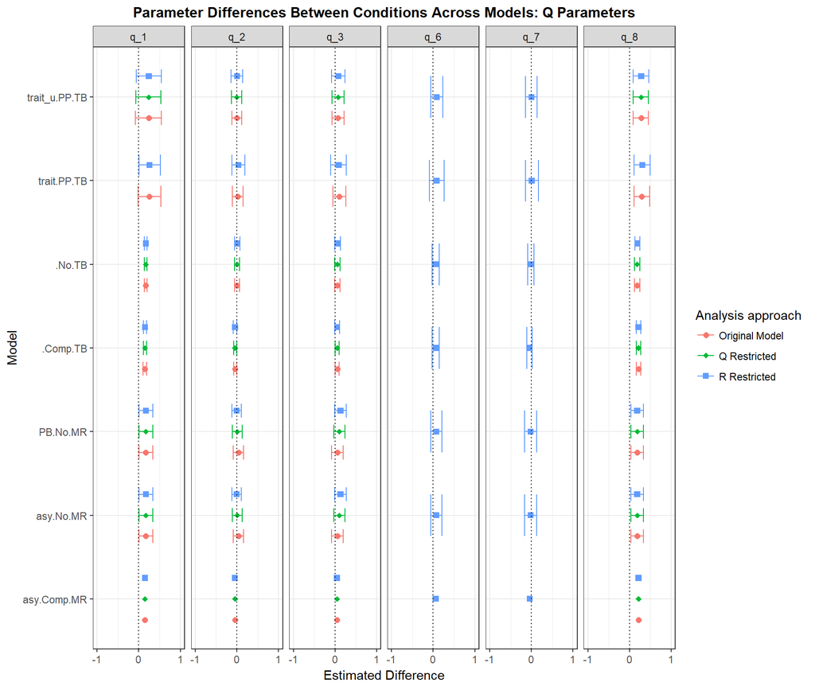

**R Parameters**

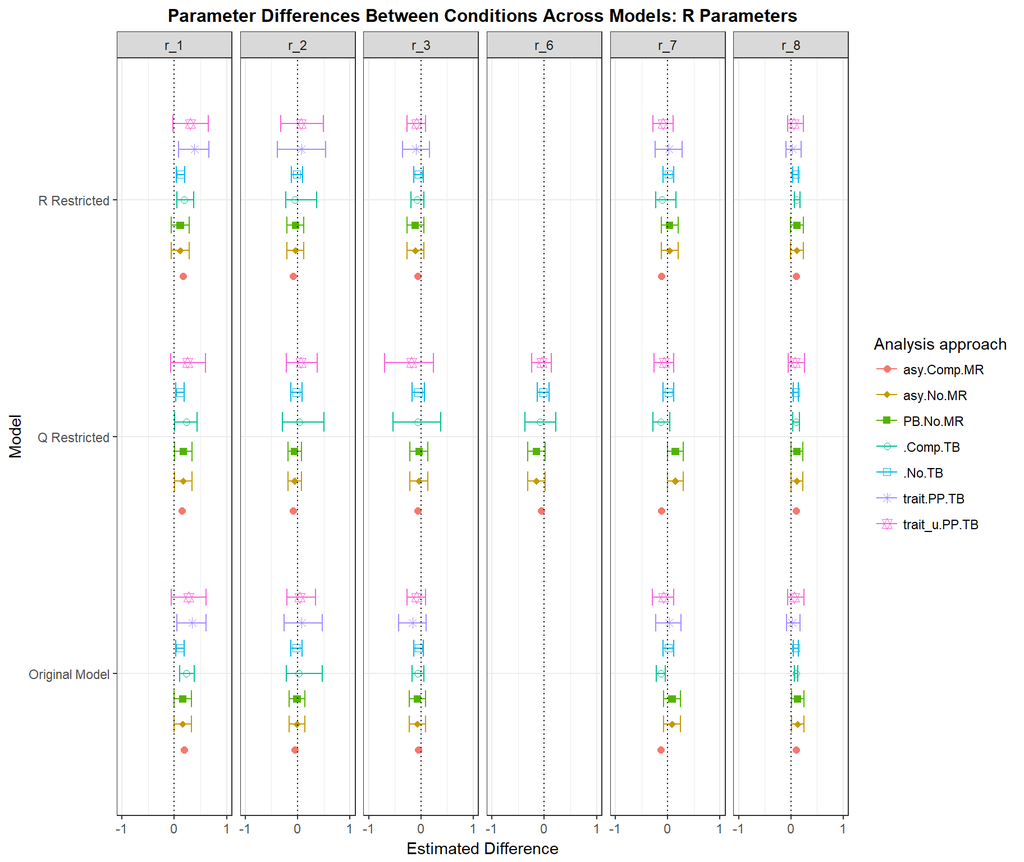

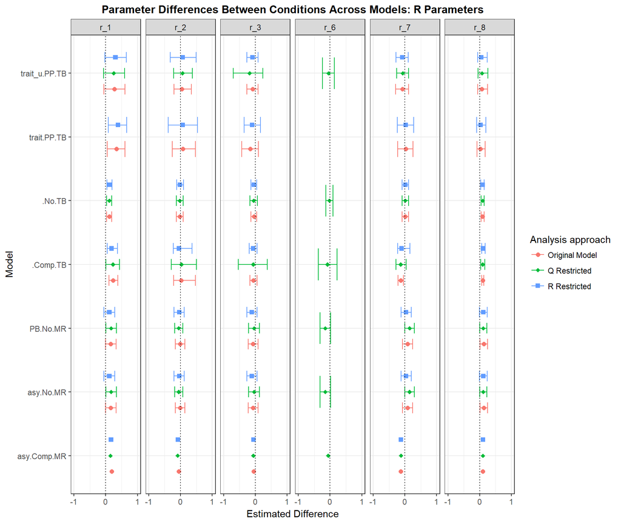

### Goodness of fit

**Model Original**

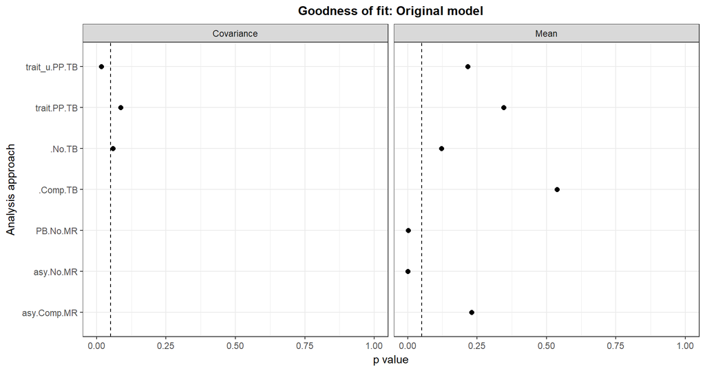

**Q restricted**

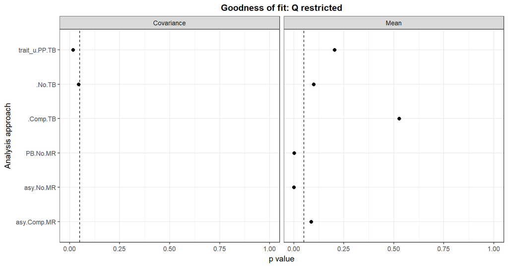

**R restricted**

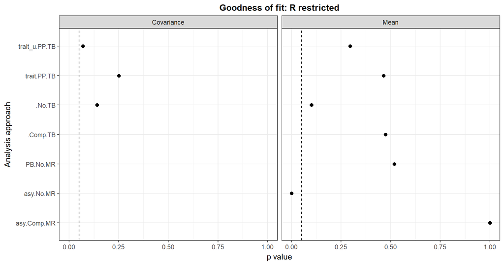

### Goodness of fit per condition

**Model Original**

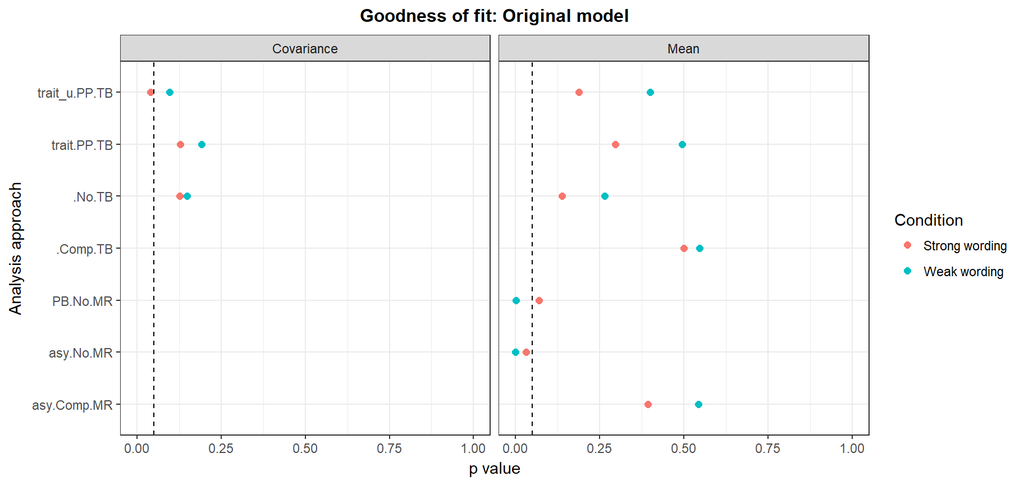

**Q restricted**

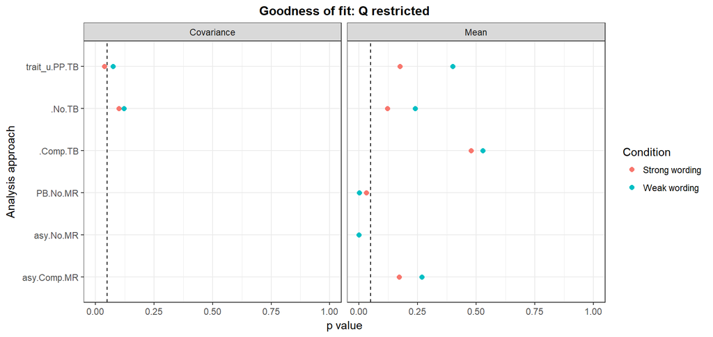

**R restricted**

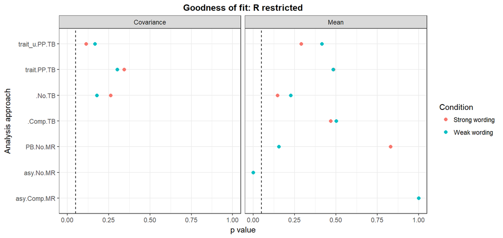